# Lab 03 - Nobel laureates

Hannah Kingham

2022-10-14

### Load packages and data

```r
library(tidyverse)
library(forcats)
```

```r
nobel <- read_csv("data/nobel.csv")
```

### Exercise 1

#### Narrative

There are 935 observations and 26 different variables. Each row represents a different prize winner (there are duplicate rows if someone won a prize more than once), row represents every prize given out.

### Exercise 2

#### Code

```r
nobel_living <- nobel %>%
  filter(!is.na(country),
         !gender %in% "org",
         is.na(died_date))
```

#### Narrative

First filtered observations where country is not NA, then for observations where gender is not org and finally for observations with died date of NA indicating they are still alive.

nobel_living is now a data frame with 228 entries, representing all nobel prize winners that are currently alive people (not organisations) and for whom country data is avaliable.

### Exercise 3

#### Code

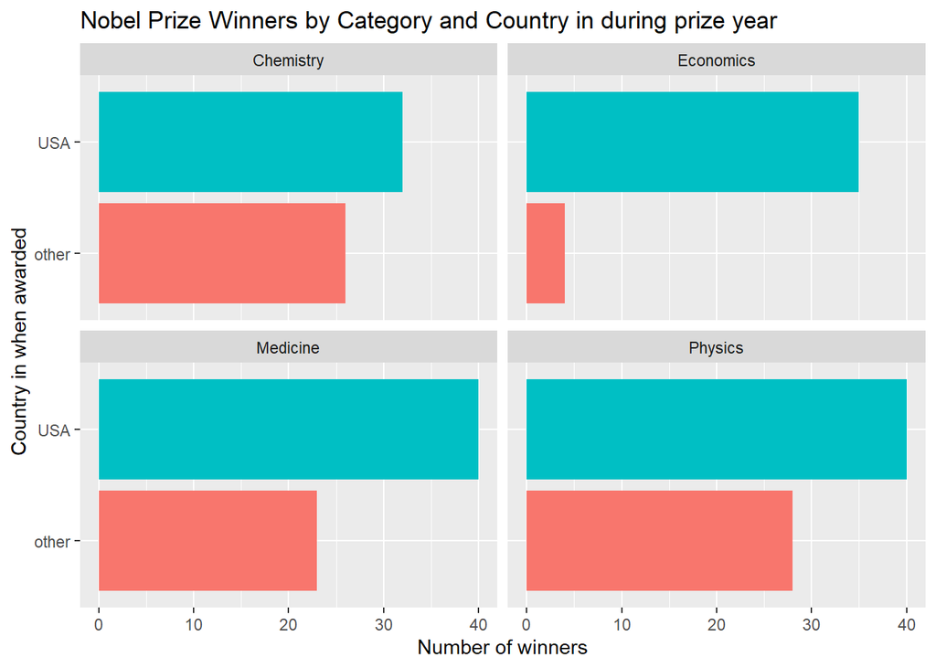

```r
nobel_living <- nobel_living %>%
  mutate(country_us =
           if_else(
             country == "USA", "USA", "other")
         )
nobel_living_science <- nobel_living %>%
  filter(category %in% c("Physics",
                         "Chemistry",
                         "Medicine",
                         "Economics")
         )
ggplot(nobel_living_science,
       mapping = aes(x = country_us, fill = country_us)) +
geom_bar()+
  facet_wrap(~category)+
  coord_flip() +
  theme(legend.position = "None")+
  labs(title = "Nobel Prize Winners by Category and Country in during prize year",
       y = "Number of winners",
       x = "Country in when awarded",
       )
```

#### Narrative

This shows very similar results to the buzzfeed article, numbers are not exactly the same but general trends and proportions are.

### Exercise 4

#### Code

```r
nobel_living_science %>%
  mutate(born_country_us =
           if_else(born_country ==
               "USA", "USA", "other"))%>%
  count(born_country_us)
```

```
## # A tibble: 2 × 2
##   born_country_us     n
##   <chr>           <int>
## 1 other             123
## 2 USA               105
```

105 of the nobel prize winners were born in the USA while 123 were born elsewhere.

### Exercise 5

#### Narrative

This again shows very similar results to the BuzzFeed article and supports their claim. We can see that a large proportion of those winning prizes while in the US were actually born elsewhere. We also see that for winners who were not in the US when they won, very few of them were born in the US.

#### Code

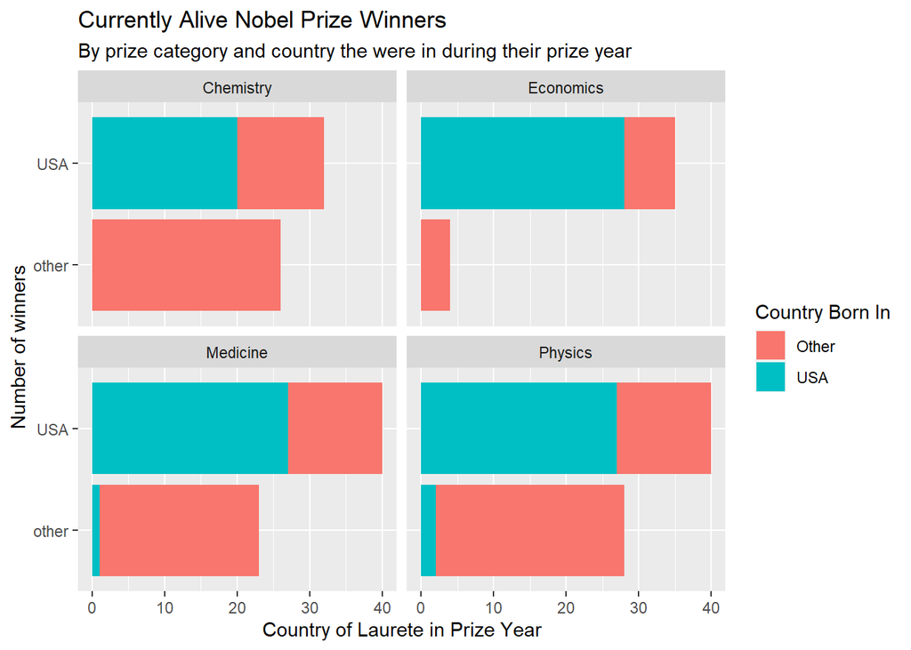

```r
nobel_living_science %>%
  mutate(born_country_us =
           if_else(born_country ==
               "USA", "USA", "Other"))%>%
  ggplot(nobel_living_science,
         mapping = aes(x = country_us)) +
  geom_bar(mapping = aes(
    fill = born_country_us
  ))+
    facet_wrap(~category)+
    coord_flip()+
    labs(title = "Currently Alive Nobel Prize Winners",
         subtitle = "By prize category and country the were in during their prize year",
         x = "Number of winners",
         y = "Country of Laurete in Prize Year",
         fill = "Country Born In")
```

### Exercise 6

#### Code

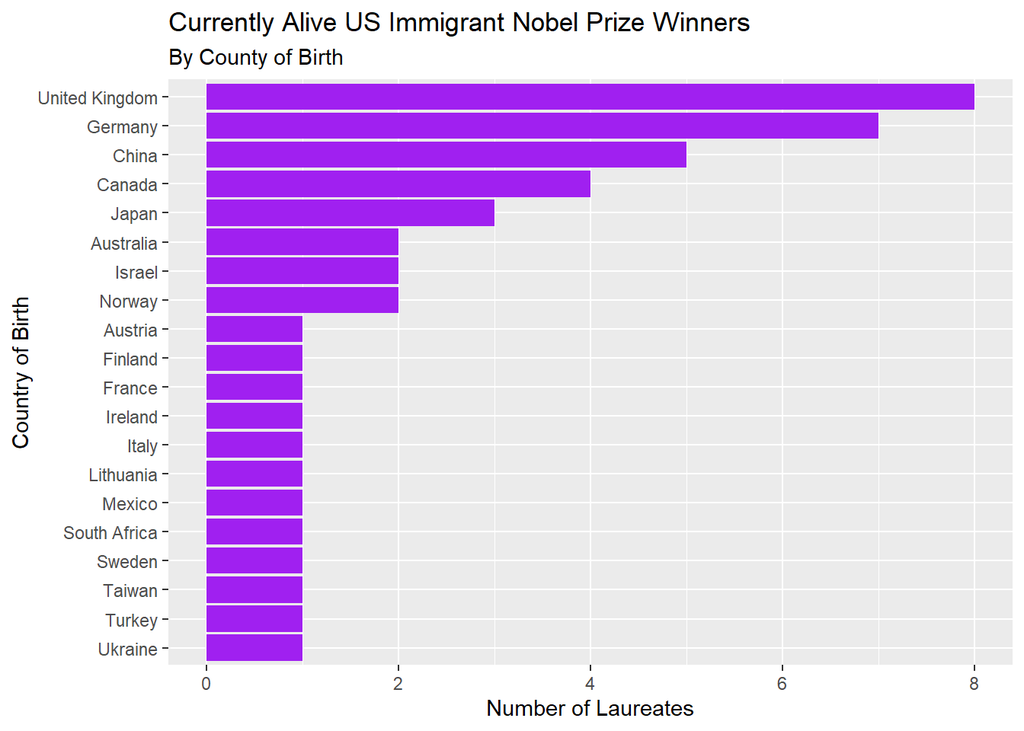

```r
new_nobel_living <- nobel_living %>%
  mutate(born_country =
           case_when(
             born_country == "Scotland" ~ "United Kingdom",
             TRUE ~ born_country))%>%
  mutate(born_country_us =
           if_else(born_country ==
               "USA", "USA", "other"))%>%
  filter(country_us == "USA" &
         born_country_us == "other")

ggplot(new_nobel_living,
       mapping = aes(
         x =fct_rev(fct_infreq(born_country))))+
geom_bar(fill = "purple")+
coord_flip()+
labs(
  title = "Currently Alive US Immigrant Nobel Prize Winners",
  subtitle = "By County of Birth",
  y = "Number of Laureates",
  x = "Country of Birth")
```

```r
new_nobel_living %>%
  count(fct_infreq(born_country))
```

```
## # A tibble: 20 × 2
##    `fct_infreq(born_country)`     n
##    <fct>                      <int>
##  1 United Kingdom                 8
##  2 Germany                        7
##  3 China                          5
##  4 Canada                         4
##  5 Japan                          3
##  6 Australia                      2
##  7 Israel                         2
##  8 Norway                         2
##  9 Austria                        1
## 10 Finland                        1
## 11 France                         1
## 12 Ireland                        1
## 13 Italy                          1
## 14 Lithuania                      1
## 15 Mexico                         1
## 16 South Africa                   1
## 17 Sweden                         1
## 18 Taiwan                         1
## 19 Turkey                         1
## 20 Ukraine                        1
```

#### Narrative

According to the data Germany and the UK are joint most common for the birth country of currently alive nobel prize winners who won the award while based in the US. This, however, is not true since Scotland is a separate country. If we change all Scotland observations to united kingdom, we can see that the UK has the most winners.